# Sentiment Analysis of Asian American Tweets During the COVID-19 Pandemic and the Surge of Asian-American Hate Crimes

Jonathon Sun

Ying Dai

Joyce Zhang

4/20/2021

# Executive Summary

Asian American hate crimes has been on the rise since the beginning of covid-19 with rhetoric such as Kung-flu and the China virus. Due to the current social climate, twitter data using the search term Asian American is more crucial than ever to understand how Asian Americans are framed within the broader racial context of the United States. As such, the purposes of our final project are to 1) explore how Asian Americans are framed and described in social media during the COVID-19 pandemic; and 2) predict what common words are most likely to increase the likelihood of a tweet being retweeted on the topics around Asian Americans. Using data from Asian-American related tweets over the past five-months Twitter data between November 30th, 2020 2020 to April 1st, 2021 were collected using a tool called “ If This, Then That (IFTTT)” (https://ifttt.com/). We propose to use text mining, lasso, logistic regression, random forest, and neuro networks to conduct our analysis. Specifically using LASSO and logistic regression to build a “best” model to predict a tweet gets retweeted and builds a separate model using random forest and neuro networks respectively to compare which approach works best.

#Theoretical Framework There have been two theories which extraploate the Asian American racial positioning in the United States, Kim’s (1999) theory on racial triangulation and Bonilla-Silva’s (2004) theory on a tri-racial system of racial stratification. Kim’s (1999) theory on racial triangulation argues that Asian Americans were positioned to be valorized by White people; while being left out of civic opportunities. Despite this relative position, Asian Americans were portrayed similarly to Black Americans and seen as lazy, dishonest, irresponsible, and thieving. Bonilla-Silva (2004) theorizes that a tri-racial system of racial stratification exists: White, Honorary White, and Collective Black, a structure similar to Latin American and Caribbean societies. Both of these theories agree that regardless of who occupies the space between Black and White, a tri-racial system will continue to uphold white supremacy as a structural force (Bonilla-Silva, 2004). As Asian Americans have been positioned in a third space between the Black and White binary, Asian Americans have been labeled as the model minority. Some may argue that this is a positive stereotype; however, this is problematic in that it: (1) Frames Asian Americans as universally successful and reinforces color blind ideologies, (2) assumes Asian Americans are problem free and do not require resources and support, and (3) pits Asian Americans against other minority groups.

Given Asian American’s racial positioning being situated between the black and white binary as the model minority, covid-19 shows how that position can easily be removed as, Asian Americans are being discriminated against in more aggressive and straight forward ways. Since the beginning of Covid-19 Asian American owned businesses have been boycotted and in March 2021, we saw that 7 Asian American women were murdered. While these events show the precarious positioning of Asian Americans as the “Model Minority”, these events do not show how people engage and talk about these kinds of events. As such, this provided us two broad questions to explore the shift in Asian American sentiment.

1. Explore how Asian Americans are framed and described in social media Twitter during the covid-19 pandemic, and further analyze the emotions contained in tweets.
2. Predict what common words are most likely to increase the likelihood of a tweet being retweeted on the topic around Asian Americans.

## RQ 1: Conclusion

The first research question we had was to explore how Asian Americans are framed and described in social media during the COVID-19 pandemic and second explore what words are predictive of overall positive/negative sentiment scores. The emotion classification shows that most of the tweets includes a mixture of fear, trust, and anger which is consistent with how most people are feeling in general. However; what is interesting is that there are tweets that have a high sense of trust, given the challenges of discrimination and boycotting Asian American businesses, meaning that there is still a feeling of trust. The emotions in text also indicate that despite there being trust, most tweets included negative emotions over positive emotions.

# Full Data

## Cleaning the Data

The original datasets were uploaded as excel documents and as such needed to be read in using `read_excel`. In total there were 45 different excel spreadsheets that needed to be read in and merged together.

Once all the spreadsheets were merged each of the tweets needed to be cleaned and new columns added. First we created a new column of data that extracted the individual that rewteeted the tweet. Next the phrase “RT” needed to be removed. “RT” indicates that the tweet was retweeted. After this we removed the columns twitterlink and weblink.

Once the original dataset was cleaned, we created some extra variables. Based on the date and time, we created two more columns, one that kept track of the weekday and the time that the tweet was retweeted. Additionally, we built another column that counted the amount of characters and hashtags in each tweet. Finally the last column that was built, kept track of how long it took for a tweet to be rewteeted. For example, a tweet could have been originally tweeted on Friday at 12:00 pm then next time this tweet was retweeted Friday at 1:30 pm. The time to retweet column would document that that an 1 hour and 30 minutes passed since this was first tweeted.

```
##  [1] "DateTime"      "Date"          "Time"          "Username"
##  [5] "Tweet"         "Twitterlink"   "Weblink"       "Retweet"
##  [9] "Weekday"       "Month"         "Character_Num" "Hashtag_Num"
## [13] "ID"            "Total"         "First_Tweet"   "Time_to_RT"
```

[output not shown]

After each of these extra columns were built, the original dataset was summarized to only include unique tweets and their summarized averages. This way, we were able to tell whether a tweet has been retweeted or not, and if so, how many times. Additionally, we were able to build two more columns, one that kept track of how many days the tweet persisted for and an average of retweets per day.

Although all these variables were not included in the analysis other the column indicating whether a tweet is being retweeted or not, we have included a summary statistics about these variables.

# RQ 1: Explore how Asian Americans are framed and described in social media during the COVID-19 pandemic

To begin the textual analysis, we began by extracting only the tweets from the unique tweets. This data is then cleaned to remove usernames, hashtags, digits, emojis and any links included in the tweet. The data was taken from the text column and transformed so each word is a column that describes the frequency of the word in a tweet called a corpus. To finish cleaning the corpus has the punctuation removed, all words changed to lower case, stop words removed, white space striped, numbers removed, and stem words turned on. When stem words is turned on the root of each word is included rather than the whole word. In additiona to these, 4 other words were removed, Asian American, Asian, American and Black. The reason for remove Asian American, Asian, and American, was because the tweets were selected because they included those words. The word Black was removed, because in a future analysis the word Black is associated as negative rather than Black Americans as a neutral connatation.

## visualize wordcloud

To investigate how Asian Americans were described on Twitter, we only focus on the contents of each unique tweet. Based on the previously created word frequency matrix, we used the word cloud function to visualize the words that were frequently appeared in included tweets.

From the word cloud below we can see that the word “community” appeared with the highest frequency, followed by “hate”, “white”, “people”, “support”, “violence”, etc. Without putting these words into each tweet, we cannot know much about how these words were used on Twitter to describe Asian Americans. However, considering the presidential election at the beginning of our data collection, as well as the continuing COVID-19 pandemic and recently surging Asian hate crimes, we consider people tend to discuss Asian Americans within a community context. People on Twitter keep up with current events and use social media such as Twitter to raise public awareness regarding events that jeopardize Asian Americans’ safety and benefits and call for support.

```
## <<TermDocumentMatrix (terms: 236, documents: 32135)>>
## Non-/sparse entries: 172592/7411268
## Sparsity           : 98%
## Maximal term length: 10
## Weighting          : term frequency (tf)
## Sample             :
##            Docs
## Terms       1330 14146 1484 17174 2537 2668 31606 648 702 8233
##   can          0     0    1     0    0    1     0   1   0    0
##   communiti    0     0    2     0    1    0     0   0   0    0
##   first        0     0    0     0    0    0     0   4   0    0
##   hate         0     0    0     2    0    0     0   0   2    0
##   like         0     1    0     0    0    0     0   0   0    0
##   peopl        0     0    0     0    0    0     3   0   0    0
##   stand        0     0    0     0    1    0     0   0   0    0
##   support      0     0    2     0    0    0     0   0   0    0
##   white        1     2    0     0    0    3     3   1   1    1
##   will         0     0    0     0    0    1     0   2   0    0
```

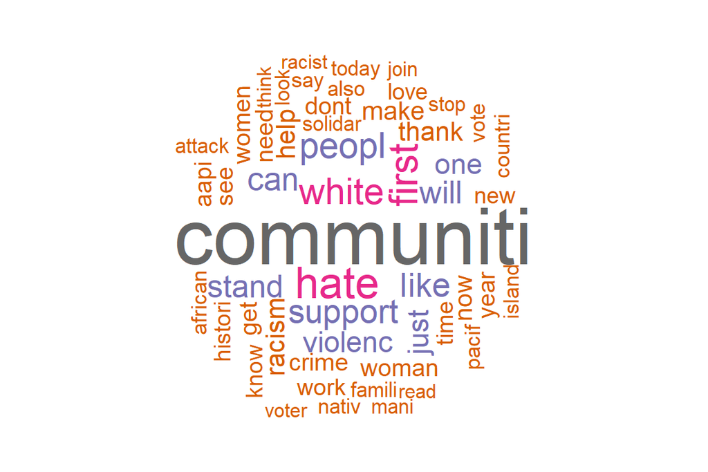

## Get overall sentiment score

### Syuzhet vector

We next calculated the overall sentiment of the text file using the `Syuzhet` package. This package uses the bag-of-words approach, where the sentiment of each text is determined on the basis of individual words, while neglecting the role of syntax and grammar. The words contained in text were compared against one or more lexicons where positive and negative words are listed and associated with a degree of positive/negative sentiment, and eight basic emotions including anger, anticipation, disgust, fear, joy, sadness, surprise, and trust, defined by Plutchik (Reference: Plutchik R. The Nature of Emotions. American Scientist. 2001;89(4):344). Syuzhet also include other two lexicons namely Afinn and Bing. Afinn was developed by Finn Årup Nielsen. Bing was developed by Minqing Hu and Bing Liu.

```
##    Min. 1st Qu.  Median    Mean 3rd Qu.    Max.
##  -275.0   -68.8     0.0   -68.8     0.0     0.0
```

### Bing and Affin vector

The mean pulled by Bing and Afinn are both negative, although their values are different. This is understandable since each lexicon uses a slightly different criterion and rating scale to classify text.

```
##    Min. 1st Qu.  Median    Mean 3rd Qu.    Max.
##    -412    -103       0    -103       0       0
```

```
##    Min. 1st Qu.  Median    Mean 3rd Qu.    Max.
##    -368     -92       0     -92       0       0
```

### Normalize scale and compare three vectors

Since each lexicon based on different rating scale, we used the sign function to convert all positive number to `1`, all zeros remain `0`, and all negative numbers to `-1` and compare how they are different in word classification. The table below shows that the ratings of the first three document judged by Syuzhet, Bing, and Affin, respectively. From the table we can see the first meaningful element of the text file was rated as negative by all three methods.

```
##      [,1] [,2] [,3] [,4]
## [1,]   -1    0    0    0
## [2,]   -1    0    0    0
## [3,]   -1    0    0    0
```

## Emotion classification

We further conducted emotion classification using the NRC lexicon. This lexicon is a list of English words and their associations with eight basic emotions (anger, fear, anticipation, trust, surprise, sadness, joy, and disgust) and two sentiments (negative and positive).

### Get eight emotion sentiment score

Using the NRC method, we get the eight emoion sentiment scores. From the bar chart below we can see the highest emotion contained in Asian-American Tweets is fear, followed by trust, anger, and sadness, etc.

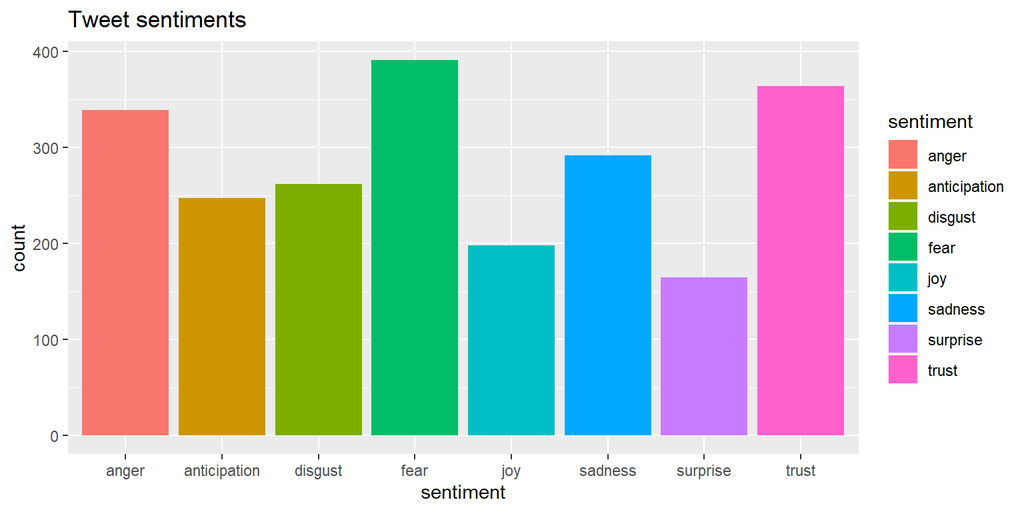

Using the NRC lexicon, the eight emotions were futhered classifed into overall positive/negative domain. From the bar chart below we can see that the overall negative emotions consisted of about 60% of the whole Tweets.

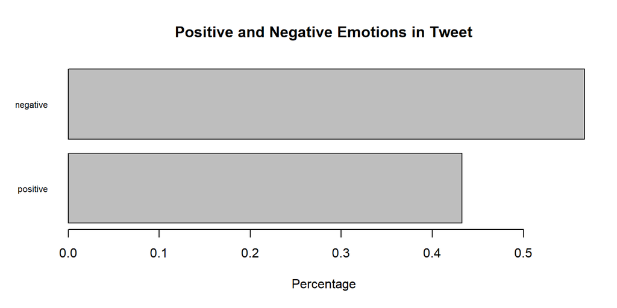

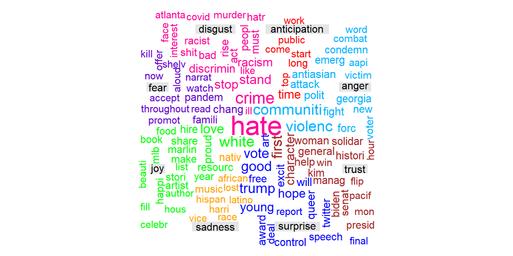

# RQ 1b: Explore what words are predictive of overall NRC positive/negative sentiment scores

After visualizing the words in tweets, we conducted a followup analysis to explore what words are predictive of an overall positive or negative tweet. Therefore, in the second part of the analysis of the first research question, we created a binary variable for each tweet which indicates the positive or negative sentiment the tweet has. The binary variable was derived from the total sentiment score which was calculated using the positive score minus the negative score.

To begin exploring what words were predictive of overall positive or negative sentiment scores, the data was split into testing and training data and then transformed into factor. We reserved 10000 observations randomly as our test data (`data2.test`) and the remaining 22135 as the training data (`data2.train`).

## Analsysi 1: LASSO

Lasso helps us reduce the amount of variables in our analysis. We extract useful variables using `lambda.1se` and decided on 143 words that did not have beta values of 0 or close to zero.

## Analysis 2: Relaxed LASSO

We further run our relaxed `LASSO`. Input variables are chosen by `LASSO` and we get a regular logistic regression model. The relaxed LASSO then selects only significant variables that have a p-value less than 0.05.

## Analysis 3: Positive/negative sentiment word cloud

[figure not shown]

**Negative word cloud**:

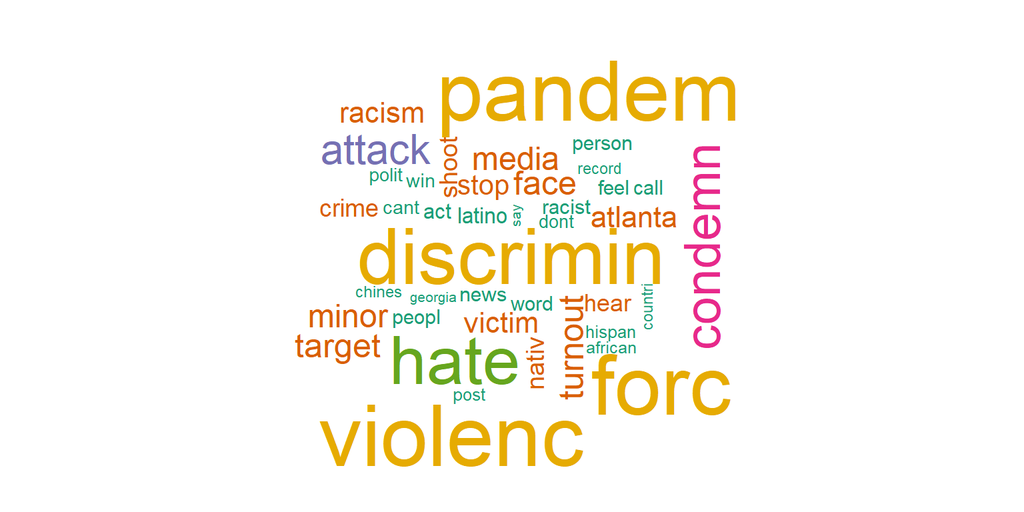

# RQ 2: Predict what common words are most likely to increase the likelihood of a tweet be retweeted on the topics around Asian Americans.

We used `LASSO` then Logistic regression to find the important variables. From here we will then create word clouds based on the beta values. In addition, we will run `randomForest` and nueronet. Each of these methods will then be compared to each other to determine the best model.

## Analsysi 1: LASSO

We resume our analyses by loading the `LASSO` results here. We extract useful variables using `lambda.1se`

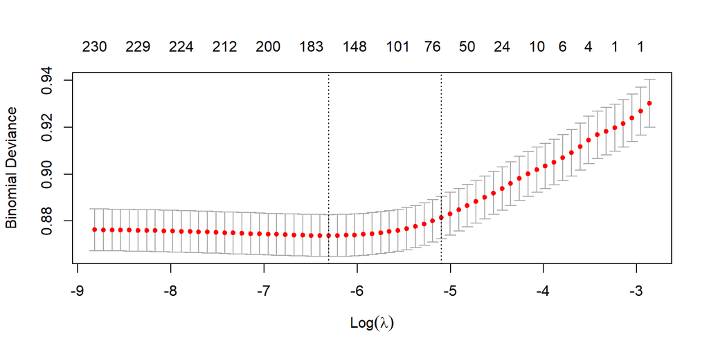

```
##    Length     Class      Mode
##        69 character character
```

Next we evaluate the testing performance of `LASSO` solution. We found the LASSO testing errors is 0.176, while the area under the curve is 0.656.

## Analysis 2: Relaxed LASSO

As an alternative model we will run our relaxed `LASSO`. Input variables are chosen by `LASSO` and we get a regular logistic regression model. Once again it is stored as `result.glm` in `TextMining.RData`.

Use the testing data we get mis-classification error for logistic regression equals to 0.178, and the area under the curve equals to 0.661.

```
## [1] 0.426
```

## Analysis 3: Word cloud of words with increasing chance of being retweeted

**Retweeted word cloud**:

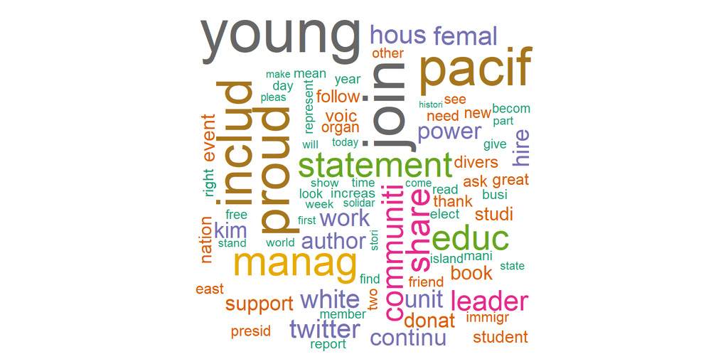

## Analysis 4: Random forest

Random forest for classify whether a tweet get retweeted by building a tree with bootstrap sample recursively when the minimum sample size n is met. For each variable, the algorithm finds the best split point to miminize the misclassification error by majority vote. After finding the best variables and split points, the node was then split into two, with the end note output the majority vote with 0 or 1.

We first ran 500 trees with mtry=sqrt(p), and from the plot below we found that after 200 trees, the oob error becomes stable and thus 200 trees are good enough.

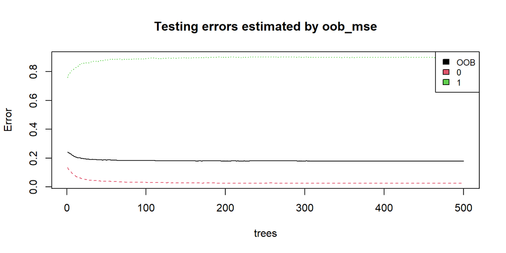

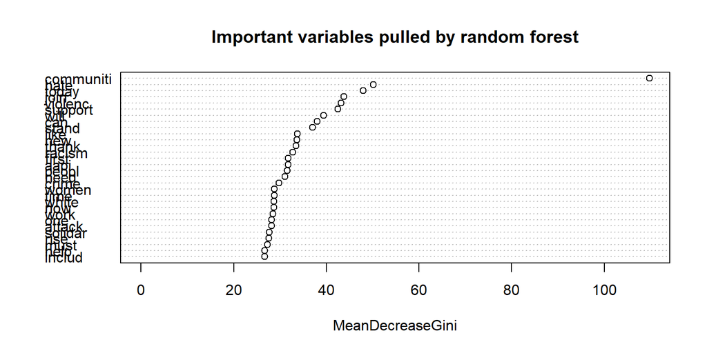

```
## Confusion Matrix and Statistics
##
##           Reference
## Prediction    0    1
##          0 8023 1639
##          1  205  133
##
##                Accuracy : 0.816
##                  95% CI : (0.808, 0.823)
##     No Information Rate : 0.823
##     P-Value [Acc > NIR] : 0.971
##
##                   Kappa : 0.073
##
##  Mcnemar's Test P-Value : <2e-16
##
##             Sensitivity : 0.9751
##             Specificity : 0.0751
##          Pos Pred Value : 0.8304
##          Neg Pred Value : 0.3935
##              Prevalence : 0.8228
##          Detection Rate : 0.8023
##    Detection Prevalence : 0.9662
##       Balanced Accuracy : 0.5251
##
##        'Positive' Class : 0
##
```

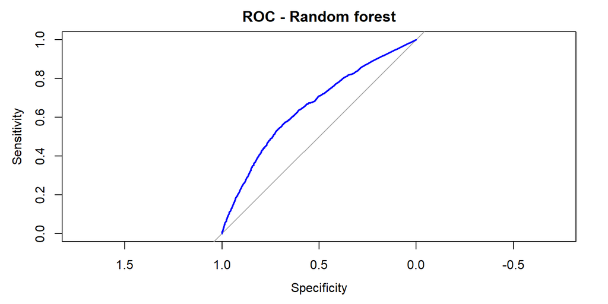

```
##
## Call:
## roc.default(response = data2.test$total.score, predictor = pred[,     "1"], plot = TRUE, col = "blue", main = "ROC - Random forest")
##
## Data: pred[, "1"] in 8228 controls (data2.test$total.score 0) < 1772 cases (data2.test$total.score 1).
## Area under the curve: 0.655
```

```
## [1] "Accuracy % of random forest:  0.8157"
```

## Analysis 5: Neuronet

Finally for our last analysis we ran nueronet, neuro net consists of an input layer, a set of hidden layers and an output layer. Each layer also includes a number of features for each layer which are then connected to a neuron.

First we need to define our model. In defining our model, we specified a model with a two hidden lyaers. One layer that included 16 neurons and one that included 8 neurons. Our final layer only included only two neurons to predict a binary response.

Having more hidden units (a higher-dimensional representation space) allows your network to learn more-complex representations, but it makes the network more computationally expensive and may lead to learning unwanted patterns. Here we use 16 neurons in the first layer and 8 neurons in the second layer.

```
## Model
## Model: "sequential"
## ________________________________________________________________________________
## Layer (type)                        Output Shape                    Param #
## ================================================================================
## dense_2 (Dense)                     (None, 16)                      3776
## ________________________________________________________________________________
## dense_1 (Dense)                     (None, 8)                       136
## ________________________________________________________________________________
## dense (Dense)                       (None, 2)                       18
## ================================================================================
## Total params: 3,930
## Trainable params: 3,930
## Non-trainable params: 0
## ________________________________________________________________________________
```

From the graph below we see that by about 5 epochs our validation loss has bottomed out and we receive no further benefit from additional iterations.

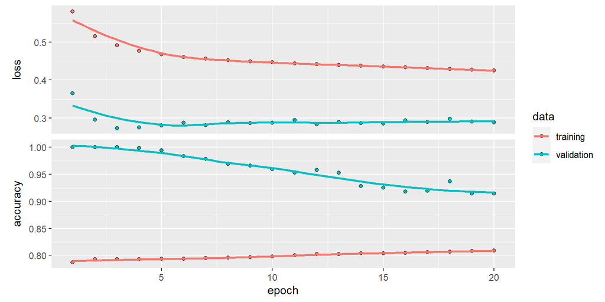

Now we use the whole data set to get the final NN prediction model. The model again has two layers with 16 and 8 neurons in each layer, and has 5 Epochs.

We then use the evaluation function to assess our performance on the validation data to report a final performance of the model built. Our accuracy on the validation data reaches 82.3% with only two fully connected layers! Meaning that we correctly classified 82.3% of the tweets got retweeted or not (this is a misclassification error of 0.177).

# Conclusion

## RQ 1: Conclusion

The first research question we had was to explore how Asian Americans are framed and described in social media during the COVID-19 pandemic and second explore what words are predictive of overall positive/negative sentiment scores. The emotion classification shows that most of the tweets includes a mixture of fear, trust, and anger which is consistent with how most people are feeling in general. However; what is interesting is that there are tweets that have a high sense of trust, given the challenges of discrimination and boycotting Asian American businesses, meaning that there is still a feeling of trust. The emotions in text also indicate that despite there being trust, most tweets included negative emotions over positive emotions.

## Recommendation

Our study has several implications. First, the high percentage of fear, sadness, angry feelings remain relatively high on Asian-American-related tweets during the past few months. Considering words that frequently appeared in these negative emotion domains are relevant to the surge of Anti-Asian and Asian hate crimes during the past few months. This calls for more public awareness of providing support to Asian-Americans. Regarding how to increase a tweet to be retweeted, we recommend that emphasizing the Asian-American community, follow the current events, and increase public awareness of providing support to Asian-Americans.